# Introduction to R

Yuan Chai

2022-09-28

[figure not shown]

## **Instructors**

Yuan Chai (chaix026@umn.edu)  
Ali Joglekar (joglekar@umn.edu)

## Introduction to R Basics

### Use R as a calculator

Calculate 8/5

```r
8/5
```

```
## [1] 1.6
```

### R Objects

In R, an analysis is normally broken down into a series of steps. Intermediate results are stored in **objects**. In fact, the fundamental design principle underlying R is “**everything is an object**”.

### Variables

- Variable names must start with a letter and can only contain letters, numbers, periods, and underscores.
- Examples of allowable variable names:
  - `x`, `A`, `my_Variable`, `variable3`, `my.other.variable`
- Try to make your variables mean something to you so you remember what they are
  - Example: `test_score`, `reaction_time`, etc.
- Variable names are case-sensitive, so you could have variables called `a` and `A`, and they would be distinct.

```r
# Variables
# A variable is the name you assign to stand for some number or set of numbers.
x <- 8

# You can also make a variable equal the result of a computation:
x <- 8*5

# You can find the current value of a variable by entering its name:
x
```

```
## [1] 40
```

You can use variables in calculations just like they were numbers:

```r
y <- x*7
y
```

```
## [1] 280
```

#### Basic variable types

Basic variable types include:

- numeric
- character
- logical

```r
# Declare variables of different types
my_numeric <- 42
my_character <- "universe"
my_logical <- FALSE

# Display variables
my_numeric
```

```
## [1] 42
```

```r
my_character
```

```
## [1] "universe"
```

```r
my_logical
```

```
## [1] FALSE
```

### Functions

Functions are computations that already exist in R. They perform computations of the values you provide. For example: `sum()`, `prod()`, `log()`, ect.

- Functions work like a black box;
- Argument matched by position or by name;
- Function arguments can have defaults.

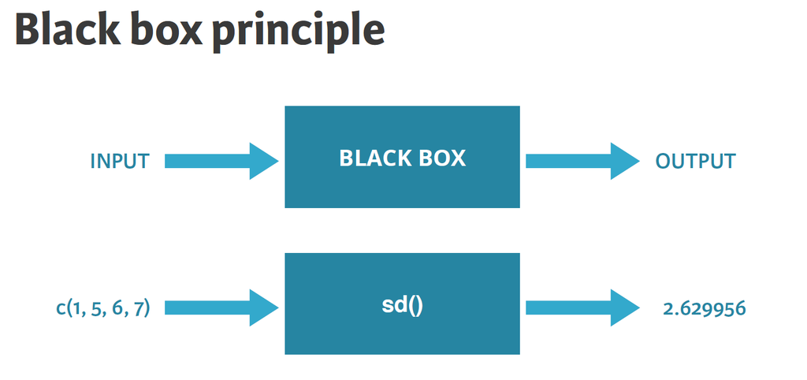

```r
sum(3,4,5,6)
```

```
## [1] 18
```

```r
prod(3,4,5,6)
```

```
## [1] 360
```

### Vectors

- Vectors represent sets of measurements (e.g. a score for each person).
- Vectors are created in R using the special `c()` function, which means concatenate.
- `c()` takes a set of numbers or vectors and concatenates them into one vector.

**Create vectors**

```r
# create vectors
vec1 <- c(9,8,7,6)
vec2 <- c(1,2,3,4)

# display vectors
vec1
```

```
## [1] 9 8 7 6
```

```r
vec2
```

```
## [1] 1 2 3 4
```

Patterned vectors

```r
vec_interval <- 1981:2005
vec_interval
```

```
##  [1] 1981 1982 1983 1984 1985 1986 1987 1988 1989 1990 1991 1992 1993 1994 1995
## [16] 1996 1997 1998 1999 2000 2001 2002 2003 2004 2005
```

```r
vec_seq <- seq(from=2, to=20, by=2)
vec_seq
```

```
##  [1]  2  4  6  8 10 12 14 16 18 20
```

### Matrix

Create a matrix

```r
# Create a 2x3 matrix containing the elements 1:6, by column
A <- matrix(1:6, nrow=2)
A
```

```
##      [,1] [,2] [,3]
## [1,]    1    3    5
## [2,]    2    4    6
```

Get dimensions of a matrix

```r
# Dimension
dim(A)
```

```
## [1] 2 3
```

```r
nrow(A)
```

```
## [1] 2
```

```r
ncol(A)
```

```
## [1] 3
```

Sub-setting elements of a matrix

```r
a_1_2 <- A[1, 2]
a_1_2
```

```
## [1] 3
```

### Dataframes

- If you have a set of measurements on the same set of subjects, it’s useful to organize them into a single structure called a dataframe.
- A dataframe is like a matrix, meaning it has rows and columns. Each column is a variable and each row is a subject.

#### Create a dataframe

```r
# Definition of vectors
name <- c("Mercury", "Venus", "Earth", "Mars", "Jupiter", "Saturn", "Uranus", "Neptune")
type <- c("Terrestrial planet", "Terrestrial planet", "Terrestrial planet",
          "Terrestrial planet", "Gas giant", "Gas giant", "Gas giant", "Gas giant")
diameter <- c(0.382, 0.949, 1, 0.532, 11.209, 9.449, 4.007, 3.883)
rotation <- c(58.64, -243.02, 1, 1.03, 0.41, 0.43, -0.72, 0.67)
rings <- c(FALSE, FALSE, FALSE, FALSE, TRUE, TRUE, TRUE, TRUE)

# Create a data frame from the vectors
df_planets <- data.frame(name, type, diameter, rotation, rings)
df_planets
```

```
##      name               type diameter rotation rings
## 1 Mercury Terrestrial planet    0.382    58.64 FALSE
## 2   Venus Terrestrial planet    0.949  -243.02 FALSE
## 3   Earth Terrestrial planet    1.000     1.00 FALSE
## 4    Mars Terrestrial planet    0.532     1.03 FALSE
## 5 Jupiter          Gas giant   11.209     0.41  TRUE
## 6  Saturn          Gas giant    9.449     0.43  TRUE
## 7  Uranus          Gas giant    4.007    -0.72  TRUE
## 8 Neptune          Gas giant    3.883     0.67  TRUE
```

#### Dataframe structure and subsetting

Use function `str()` to explore the structure of a dataframe, such as number of obs, number of variables, variable names, type, and variable values.

```r
str(df_planets)
```

```
## 'data.frame':    8 obs. of  5 variables:
##  $ name    : chr  "Mercury" "Venus" "Earth" "Mars" ...
##  $ type    : chr  "Terrestrial planet" "Terrestrial planet" "Terrestrial planet" "Terrestrial planet" ...
##  $ diameter: num  0.382 0.949 1 0.532 11.209 ...
##  $ rotation: num  58.64 -243.02 1 1.03 0.41 ...
##  $ rings   : logi  FALSE FALSE FALSE FALSE TRUE TRUE ...
```

Use the `df[rows, cols]` to subset rows and cols of a dataframe

```r
# diameter of Mercury (row 1, column 3)
df_planets[1, 3]
```

```
## [1] 0.382
```

```r
# Mars
df_planets[4, ]
```

```
##   name               type diameter rotation rings
## 4 Mars Terrestrial planet    0.532     1.03 FALSE
```

```r
# First 5 values of diameter column
df_planets[1:5, 'diameter']
```

```
## [1]  0.382  0.949  1.000  0.532 11.209
```

Use the `$` operator to select a variable from a dataframe

```r
# Select the variable "rings" from df_planets
rings_vector <- df_planets$rings
rings_vector
```

```
## [1] FALSE FALSE FALSE FALSE  TRUE  TRUE  TRUE  TRUE
```

Use a logical vector to select rows from a dataframe

```r
# Select planets with rings
df_planets[rings_vector, ]
```

```
##      name      type diameter rotation rings
## 5 Jupiter Gas giant   11.209     0.41  TRUE
## 6  Saturn Gas giant    9.449     0.43  TRUE
## 7  Uranus Gas giant    4.007    -0.72  TRUE
## 8 Neptune Gas giant    3.883     0.67  TRUE
```

```r
# Select planets with diameter < 1
sel_diameter <- (df_planets$diameter < 1)
sel_diameter
```

```
## [1]  TRUE  TRUE FALSE  TRUE FALSE FALSE FALSE FALSE
```

```r
df_planets[sel_diameter, ]
```

```
##      name               type diameter rotation rings
## 1 Mercury Terrestrial planet    0.382    58.64 FALSE
## 2   Venus Terrestrial planet    0.949  -243.02 FALSE
## 4    Mars Terrestrial planet    0.532     1.03 FALSE
```

Order dataframe

```r
# Use order() to create positions
positions <-  order(df_planets$diameter)

# Use positions to sort planets_df
df_planets[positions,]
```

```
##      name               type diameter rotation rings
## 1 Mercury Terrestrial planet    0.382    58.64 FALSE
## 4    Mars Terrestrial planet    0.532     1.03 FALSE
## 2   Venus Terrestrial planet    0.949  -243.02 FALSE
## 3   Earth Terrestrial planet    1.000     1.00 FALSE
## 8 Neptune          Gas giant    3.883     0.67  TRUE
## 7  Uranus          Gas giant    4.007    -0.72  TRUE
## 6  Saturn          Gas giant    9.449     0.43  TRUE
## 5 Jupiter          Gas giant   11.209     0.41  TRUE
```

## Get help

Help for a given function can be accessed directly from R using `?` operator or `help()` function.

```r
?order
```

```r
help("sum")
```

Google search is also your best friend in finding any questions related to using R

## Additional R learning resources:

- [An Introduction to R](https://cran.r-project.org/doc/manuals/r-release/R-intro.pdf)
- [R FAQ](https://cran.r-project.org/doc/FAQ/R-FAQ.html)
- [R for Data Science](https://r4ds.had.co.nz/index.html)
- [Introduction to Data Analysis with R & Reproducible Data Science](https://irsaatumn.github.io/RWorkshop18/index.html)